# LT1 Worksheet

```r
install.packages("MissMech")
```

```r
library(readr)
library(tidyverse)
library(psych)
library(mice)
library(MissMEch)
```

```
Error in library(MissMEch) : there is no package called ‘MissMEch’
```

```r
climate <- read_csv("~/Downloads/climate.csv")
head(climate)
```

| X1 | Num | AGE | GENDER | NegEmot1 | NegEmot2 | NegEmot3 | Egal1 | Egal2 | Egal3 | Ind1 | Ind2 | Ind3 | GovSupport1 | GovSupport2 | GovSupport3 |
| --- | --- | --- | --- | --- | --- | --- | --- | --- | --- | --- | --- | --- | --- | --- | --- |
| 1 | 1 | 22 | 1 | 7 | 7 | 5 | 5.6 | 3.0 | 5.5 | 4.25 | 4.50 | 5.333333 | 4 | 4.333333 | 5 |
| 2 | 4 | 22 | 1 | 4 | 5 | 5 | 5.2 | 7.0 | 6.7 | 1.50 | 1.00 | 1.000000 | 7 | 7.000000 | 7 |
| 3 | 5 | 23 | 1 | 5 | 4 | 4 | 5.4 | 6.2 | 6.1 | 2.50 | 3.00 | 2.500000 | 7 | 6.666667 | 6 |
| 4 | 6 | 23 | 1 | 5 | 5 | 5 | 6.2 | 4.6 | 5.5 | 1.75 | 2.25 | NA | 5 | 4.333333 | 5 |
| 5 | 7 | 23 | 1 | 4 | 5 | 6 | 6.0 | 4.0 | 5.2 | 1.75 | 3.50 | 2.000000 | 6 | 6.666667 | 7 |
| 6 | 8 | 23 | 1 | 6 | 3 | 5 | 6.6 | 5.4 | 5.0 | 3.50 | 4.75 | 4.500000 | 7 | 5.666667 | 4 |

### Screening

```r
describe(climate)
```

|  | vars | n | mean | sd | median | trimmed | mad | min | max | range | skew | kurtosis | se |
| --- | --- | --- | --- | --- | --- | --- | --- | --- | --- | --- | --- | --- | --- |
| X1 | 1 | 212 | 106.50 | 61.34 | 106.50 | 106.50 | 78.58 | 1.00 | 212.00 | 211.00 | 0.00 | -1.22 | 4.21 |
| Num | 2 | 212 | 163.05 | 87.46 | 162.00 | 163.13 | 110.45 | 1.00 | 316.00 | 315.00 | -0.01 | -1.16 | 6.01 |
| AGE | 3 | 212 | 23.57 | 1.26 | 23.00 | 23.42 | 1.16 | 22.00 | 28.00 | 6.00 | 1.43 | 2.41 | 0.09 |
| GENDER | 4 | 212 | 1.21 | 0.41 | 1.00 | 1.14 | 0.00 | 1.00 | 2.00 | 1.00 | 1.40 | -0.05 | 0.03 |
| NegEmot1 | 5 | 212 | 5.01 | 1.63 | 5.00 | 5.19 | 1.48 | 1.00 | 7.00 | 6.00 | -0.79 | -0.05 | 0.11 |
| NegEmot2 | 6 | 212 | 5.36 | 1.46 | 6.00 | 5.53 | 1.48 | 1.00 | 7.00 | 6.00 | -0.79 | 0.01 | 0.10 |
| NegEmot3 | 7 | 212 | 5.43 | 1.32 | 6.00 | 5.55 | 1.48 | 1.00 | 7.00 | 6.00 | -0.59 | -0.22 | 0.09 |
| Egal1 | 8 | 210 | 5.38 | 1.11 | 5.60 | 5.47 | 1.04 | 1.80 | 7.00 | 5.20 | -0.71 | 0.01 | 0.08 |
| Egal2 | 9 | 211 | 5.51 | 1.03 | 5.60 | 5.57 | 1.19 | 2.75 | 7.00 | 4.25 | -0.47 | -0.52 | 0.07 |
| Egal3 | 10 | 212 | 5.49 | 0.92 | 5.60 | 5.57 | 0.89 | 2.00 | 7.00 | 5.00 | -0.86 | 0.80 | 0.06 |

[output cut: 6 more lines]

### Missing value analysis

```
    NegEmot1 NegEmot2 NegEmot3 Egal3 Ind1 GovSupport1 GovSupport3 Egal2 Ind2 GovSupport2 Egal1 Ind3
204        1        1        1     1    1           1           1     1    1           1     1    1 0
3          1        1        1     1    1           1           1     1    1           1     1    0 1
2          1        1        1     1    1           1           1     1    1           1     0    1 1
1          1        1        1     1    1           1           1     1    1           0     1    1 1
1          1        1        1     1    1           1           1     1    0           1     1    1 1
1          1        1        1     1    1           1           1     0    1           1     1    1 1
           0        0        0     0    0           0           0     1    1           1     2    3 8
```

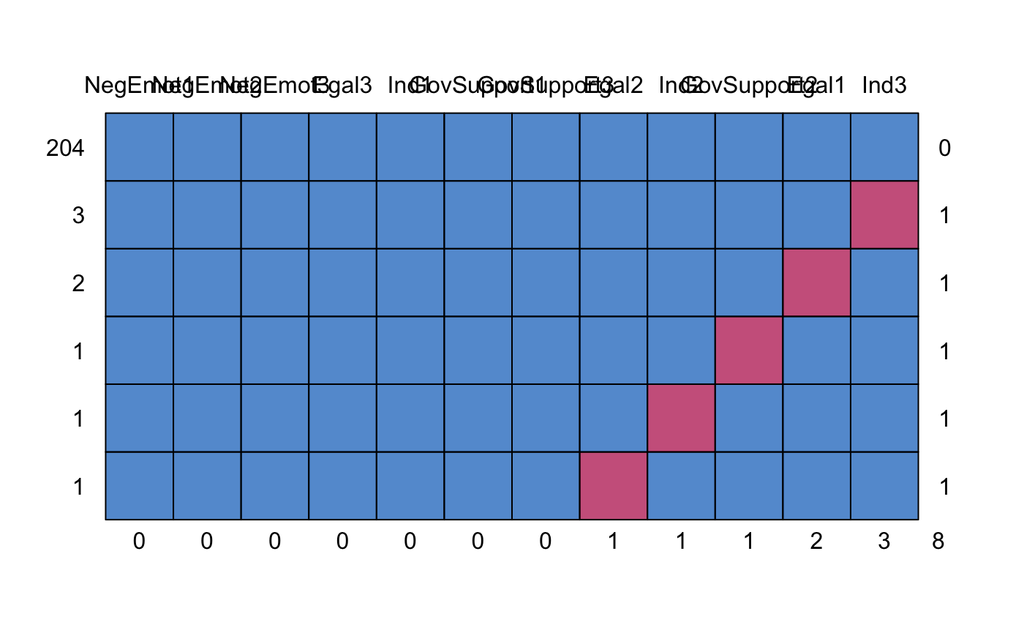

```r
climate_var <-
  climate %>%
  select(5:16) # select out only the items
md.pattern(climate_var) # run the missing data pattern function
```

204 of the cases have no missing data, whilst 8 cases have one or more data values missing.

### Missing data mechanism

This tests whether the data is missing completely at random. It carries out this test by testing the null hypothesis that states that there is equality in covariance between missing and non-missing data groups.

```r
out.MCAR.ws <- TestMCARNormality(climate_var, del.lesscases = 1)
summary(out.MCAR.ws)
```

```
Number of imputation:  1

Number of Patterns:  3

Total number of cases used in the analysis:  209

 Pattern(s) used:
          NegEmot1   NegEmot2   NegEmot3   Egal1   Egal2   Egal3   Ind1   Ind2   Ind3   GovSupport1   GovSupport2
group.1          1          1          1       1       1       1      1      1      1             1             1
group.2          1          1          1       1       1       1      1      1     NA             1             1
group.3          1          1          1      NA       1       1      1      1      1             1             1
          GovSupport3   Number of cases
group.1             1               204
group.2             1                 3
group.3             1                 2

    Test of normality and Homoscedasticity:
  -------------------------------------------

Hawkins Test:

    P-value for the Hawkins test of normality and homoscedasticity:  6.971131e-16

Non-Parametric Test:

    P-value for the non-parametric test of homoscedasticity:  0.5165865
```

The p value is above 0.05 which shows that there is significant evidence to accept the null and say that the data are missing at complete random. Because the data are missing at complete random we can use listwise deletion to remove individuals with more than 10% of their data missing. Because only 8 cases are missing, anyone with more than 1 item missing should be removed from the analysis.

### Removing cases listwise with > 10% missing

```r
climate_var$na_count <- apply(is.na(climate_var), 1, sum)
climate_var
```

| NegEmot1 | NegEmot2 | NegEmot3 | Egal1 | Egal2 | Egal3 | Ind1 | Ind2 | Ind3 | GovSupport1 | GovSupport2 | GovSupport3 | na_count |
| --- | --- | --- | --- | --- | --- | --- | --- | --- | --- | --- | --- | --- |
| 7.000000 | 7 | 5.000000 | 5.600000 | 3.00 | 5.500000 | 4.250000 | 4.500000 | 5.333333 | 4.000000 | 4.333333 | 5.000000 | 0 |
| 4.000000 | 5 | 5.000000 | 5.200000 | 7.00 | 6.700000 | 1.500000 | 1.000000 | 1.000000 | 7.000000 | 7.000000 | 7.000000 | 0 |
| 5.000000 | 4 | 4.000000 | 5.400000 | 6.20 | 6.100000 | 2.500000 | 3.000000 | 2.500000 | 7.000000 | 6.666667 | 6.000000 | 0 |
| 5.000000 | 5 | 5.000000 | 6.200000 | 4.60 | 5.500000 | 1.750000 | 2.250000 | NA | 5.000000 | 4.333333 | 5.000000 | 1 |
| 4.000000 | 5 | 6.000000 | 6.000000 | 4.00 | 5.200000 | 1.750000 | 3.500000 | 2.000000 | 6.000000 | 6.666667 | 7.000000 | 0 |
| 6.000000 | 3 | 5.000000 | 6.600000 | 5.40 | 5.000000 | 3.500000 | 4.750000 | 4.500000 | 7.000000 | 5.666667 | 4.000000 | 0 |
| 4.000000 | 4 | 4.000000 | NA | 4.00 | 4.000000 | 4.000000 | 4.000000 | 4.000000 | 4.000000 | 4.000000 | 4.000000 | 1 |
| 5.000000 | 4 | 6.000000 | 5.400000 | 5.40 | 6.100000 | 2.000000 | 1.750000 | 2.750000 | 6.000000 | 5.333333 | 4.000000 | 0 |
| 5.000000 | 4 | 5.000000 | 6.600000 | 6.20 | 6.000000 | 2.250000 | 2.250000 | 2.250000 | 7.000000 | 7.000000 | 7.000000 | 0 |
| 6.000000 | 6 | 7.000000 | 6.200000 | 5.60 | 6.400000 | 1.500000 | 2.000000 | 3.000000 | 5.000000 | 5.000000 | 4.000000 | 0 |

[output cut: 202 more lines]

```r
climate_var <-
climate_var %>%
filter(na_count <= "1")
climate_var
```

| NegEmot1 | NegEmot2 | NegEmot3 | Egal1 | Egal2 | Egal3 | Ind1 | Ind2 | Ind3 | GovSupport1 | GovSupport2 | GovSupport3 | na_count |
| --- | --- | --- | --- | --- | --- | --- | --- | --- | --- | --- | --- | --- |
| 7.000000 | 7 | 5.000000 | 5.600000 | 3.00 | 5.500000 | 4.250000 | 4.500000 | 5.333333 | 4.000000 | 4.333333 | 5.000000 | 0 |
| 4.000000 | 5 | 5.000000 | 5.200000 | 7.00 | 6.700000 | 1.500000 | 1.000000 | 1.000000 | 7.000000 | 7.000000 | 7.000000 | 0 |
| 5.000000 | 4 | 4.000000 | 5.400000 | 6.20 | 6.100000 | 2.500000 | 3.000000 | 2.500000 | 7.000000 | 6.666667 | 6.000000 | 0 |
| 5.000000 | 5 | 5.000000 | 6.200000 | 4.60 | 5.500000 | 1.750000 | 2.250000 | NA | 5.000000 | 4.333333 | 5.000000 | 1 |
| 4.000000 | 5 | 6.000000 | 6.000000 | 4.00 | 5.200000 | 1.750000 | 3.500000 | 2.000000 | 6.000000 | 6.666667 | 7.000000 | 0 |
| 6.000000 | 3 | 5.000000 | 6.600000 | 5.40 | 5.000000 | 3.500000 | 4.750000 | 4.500000 | 7.000000 | 5.666667 | 4.000000 | 0 |
| 4.000000 | 4 | 4.000000 | NA | 4.00 | 4.000000 | 4.000000 | 4.000000 | 4.000000 | 4.000000 | 4.000000 | 4.000000 | 1 |
| 5.000000 | 4 | 6.000000 | 5.400000 | 5.40 | 6.100000 | 2.000000 | 1.750000 | 2.750000 | 6.000000 | 5.333333 | 4.000000 | 0 |
| 5.000000 | 4 | 5.000000 | 6.600000 | 6.20 | 6.000000 | 2.250000 | 2.250000 | 2.250000 | 7.000000 | 7.000000 | 7.000000 | 0 |
| 6.000000 | 6 | 7.000000 | 6.200000 | 5.60 | 6.400000 | 1.500000 | 2.000000 | 3.000000 | 5.000000 | 5.000000 | 4.000000 | 0 |

[output cut: 202 more lines]

```r
climate_var <-
  climate_var %>%
  rowwise()%>%
  mutate(meanEgal = mean(c(Egal1,Egal2,Egal3), na.rm = TRUE)) %>%
  mutate(meanInd = mean(c(Ind1,Ind2,Ind3), na.rm = TRUE)) %>%
  mutate(meanGovSupport = mean(c(GovSupport1,GovSupport2,GovSupport3), na.rm = TRUE)) %>%
  mutate(meanNegEmot = mean(c(NegEmot1,NegEmot2,NegEmot3), na.rm = TRUE))
climate_var
```

| NegEmot1 | NegEmot2 | NegEmot3 | Egal1 | Egal2 | Egal3 | Ind1 | Ind2 | Ind3 | GovSupport1 | GovSupport2 | GovSupport3 | na_count | meanEgal | meanInd | meanGovSupport | meanNegEmot |
| --- | --- | --- | --- | --- | --- | --- | --- | --- | --- | --- | --- | --- | --- | --- | --- | --- |
| 7.000000 | 7 | 5.000000 | 5.600000 | 3.00 | 5.500000 | 4.250000 | 4.500000 | 5.333333 | 4.000000 | 4.333333 | 5.000000 | 0 | 4.700000 | 4.694444 | 4.444444 | 6.333333 |
| 4.000000 | 5 | 5.000000 | 5.200000 | 7.00 | 6.700000 | 1.500000 | 1.000000 | 1.000000 | 7.000000 | 7.000000 | 7.000000 | 0 | 6.300000 | 1.166667 | 7.000000 | 4.666667 |
| 5.000000 | 4 | 4.000000 | 5.400000 | 6.20 | 6.100000 | 2.500000 | 3.000000 | 2.500000 | 7.000000 | 6.666667 | 6.000000 | 0 | 5.900000 | 2.666667 | 6.555556 | 4.333333 |
| 5.000000 | 5 | 5.000000 | 6.200000 | 4.60 | 5.500000 | 1.750000 | 2.250000 | NA | 5.000000 | 4.333333 | 5.000000 | 1 | 5.433333 | 2.000000 | 4.777778 | 5.000000 |
| 4.000000 | 5 | 6.000000 | 6.000000 | 4.00 | 5.200000 | 1.750000 | 3.500000 | 2.000000 | 6.000000 | 6.666667 | 7.000000 | 0 | 5.066667 | 2.416667 | 6.555556 | 5.000000 |
| 6.000000 | 3 | 5.000000 | 6.600000 | 5.40 | 5.000000 | 3.500000 | 4.750000 | 4.500000 | 7.000000 | 5.666667 | 4.000000 | 0 | 5.666667 | 4.250000 | 5.555556 | 4.666667 |
| 4.000000 | 4 | 4.000000 | NA | 4.00 | 4.000000 | 4.000000 | 4.000000 | 4.000000 | 4.000000 | 4.000000 | 4.000000 | 1 | 4.000000 | 4.000000 | 4.000000 | 4.000000 |
| 5.000000 | 4 | 6.000000 | 5.400000 | 5.40 | 6.100000 | 2.000000 | 1.750000 | 2.750000 | 6.000000 | 5.333333 | 4.000000 | 0 | 5.633333 | 2.166667 | 5.111111 | 5.000000 |
| 5.000000 | 4 | 5.000000 | 6.600000 | 6.20 | 6.000000 | 2.250000 | 2.250000 | 2.250000 | 7.000000 | 7.000000 | 7.000000 | 0 | 6.266667 | 2.250000 | 7.000000 | 4.666667 |
| 6.000000 | 6 | 7.000000 | 6.200000 | 5.60 | 6.400000 | 1.500000 | 2.000000 | 3.000000 | 5.000000 | 5.000000 | 4.000000 | 0 | 6.066667 | 2.166667 | 4.666667 | 6.333333 |

[output cut: 202 more lines]

```r
climate_var <- within(climate_var, Egal2 <- ifelse(is.na(Egal2), meanEgal, Egal2))
climate_var <- within(climate_var, Ind2 <- ifelse(is.na(Ind2), meanInd, Ind2))
climate_var <- within(climate_var, GovSupport2 <- ifelse(is.na(GovSupport2), meanGovSupport, GovSupport2))
climate_var <- within(climate_var, Egal1 <- ifelse(is.na(Egal1), meanEgal, Egal1))
climate_var <- within(climate_var, Ind3 <- ifelse(is.na(Ind3), meanInd, Ind3))
```

```
 /\     /\
{  `---'  }
{  O   O  }
==>  V <==  No need for mice. This data set is completely observed.
 \  \|/  /
  `-----'

    NegEmot1 NegEmot2 NegEmot3 Egal1 Egal2 Egal3 Ind1 Ind2 Ind3 GovSupport1 GovSupport2 GovSupport3 na_count meanEgal
212        1        1        1     1     1     1    1    1    1           1           1           1        1        1
           0        0        0     0     0     0    0    0    0           0           0           0        0        0
    meanInd meanGovSupport meanNegEmot
212       1              1           1 0
          0              0           0 0
```

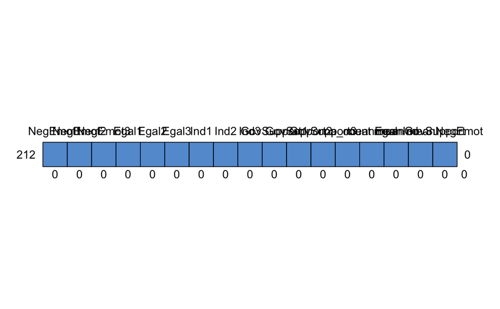

```r
md.pattern(climate_var) # run the missing data pattern function
```

### Model diagnostic

```r
lm.model <-
  lm(meanGovSupport ~ meanNegEmot + meanEgal + meanInd, data = climate_var)
summary(lm.model)
```

```
Call:
lm(formula = meanGovSupport ~ meanNegEmot + meanEgal + meanInd,
    data = climate_var)

Residuals:
     Min       1Q   Median       3Q      Max
-3.05280 -0.79188 -0.08169  0.81631  2.69254

Coefficients:
            Estimate Std. Error t value Pr(>|t|)
(Intercept)  2.32262    0.71092   3.267  0.00127 **
meanNegEmot  0.05849    0.08181   0.715  0.47545
meanEgal     0.38796    0.11920   3.255  0.00133 **
meanInd      0.06882    0.08123   0.847  0.39788
---
Signif. codes:  0 ‘***’ 0.001 ‘**’ 0.01 ‘*’ 0.05 ‘.’ 0.1 ‘ ’ 1

Residual standard error: 1.172 on 208 degrees of freedom
Multiple R-squared:  0.0865,    Adjusted R-squared:  0.07332
F-statistic: 6.565 on 3 and 208 DF,  p-value: 0.0002918
```

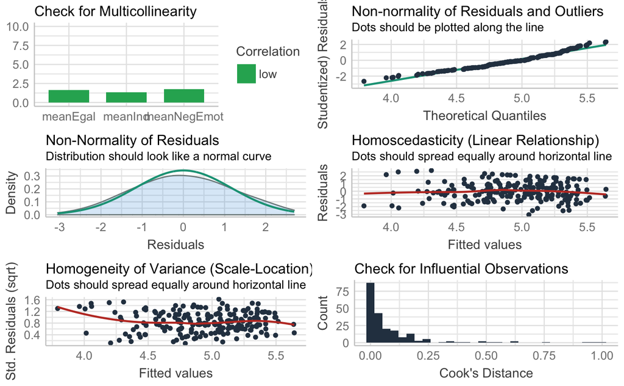

```r
library(performance)
check_model(lm.model)
```

The residuals appear to be normally distributed, as shown by the histogram and the QQ plot(the points lie closely on the line). However, the the plot of residuales against predicted values seems to be equally distributed across fitted values, therefore can be described as homoscedastic.

### Test the linear model

```r
summary(lm.model)
```

```
Call:
lm(formula = meanGovSupport ~ meanNegEmot + meanEgal + meanInd,
    data = climate_var)

Residuals:
     Min       1Q   Median       3Q      Max
-3.05280 -0.79188 -0.08169  0.81631  2.69254

Coefficients:
            Estimate Std. Error t value Pr(>|t|)
(Intercept)  2.32262    0.71092   3.267  0.00127 **
meanNegEmot  0.05849    0.08181   0.715  0.47545
meanEgal     0.38796    0.11920   3.255  0.00133 **
meanInd      0.06882    0.08123   0.847  0.39788
---
Signif. codes:  0 ‘***’ 0.001 ‘**’ 0.01 ‘*’ 0.05 ‘.’ 0.1 ‘ ’ 1

Residual standard error: 1.172 on 208 degrees of freedom
Multiple R-squared:  0.0865,    Adjusted R-squared:  0.07332
F-statistic: 6.565 on 3 and 208 DF,  p-value: 0.0002918
```

```r
confint(lm.model)
```

```
                  2.5 %    97.5 %
(Intercept)  0.92108636 3.7241472
meanNegEmot -0.10279337 0.2197693
meanEgal     0.15296282 0.6229546
meanInd     -0.09132679 0.2289578
```

The model shows that for every unit increase in negative emotion about climate change, there is a 0.06 unit increase in positive support for government action on climate change, when egalitarianism and individualism is controlled for. However, this effect is not significant as the p value is above 0.05, therefore we can accept the null hypothesis that the relationship between negative emotions about climate change, controlling for egalitarisnism and individualism is zero. It may be that having a egalitarian worldview may explain the slight relationship as it has a significant relationship with positive government support when controlled for the other factors, therefore may act as a mediator or moderator in the relationship.